# Chapter 4

## 4.4 For-loops

1+2+…+n=n(n+1)/2 이라는 식이 확실하지 않다면 어떻게 확인을 할까?

```r
compute_s_n <- function(n){
  x <- 1:n
  sum(x)
}
```

*Sn*을 계산할 때 만약 n값을 1부터 25까지 지정한다면, 25줄을 다 써야할까? `For-loops` let us define the range that our variable takes, then change the value and evaluate expression as you loop.

```r
for(i in 1:5){
  print(i)
}
```

```
[1] 1
[1] 2
[1] 3
[1] 4
[1] 5
```

Here is the for-loop we would write for our *Sn* example:

```r
m <- 25
s_n <- vector(length=m) # create an empty vector
for(n in 1:m){
  s_n[n] <- compute_s_n(n)
}
```

이를 plot을 이용해 확인할 수 있다.

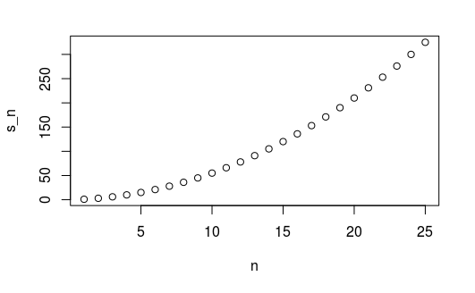

```r
n <- 1:m
plot(n, s_n)
```

```r
head(data.frame(s_n = s_n, formula = n*(n+1)/2))
```

|  | s_n | formula |
| --- | --- | --- |
| 1 | 1 | 1 |
| 2 | 3 | 3 |
| 3 | 6 | 6 |
| 4 | 10 | 10 |
| 5 | 15 | 15 |
| 6 | 21 | 21 |

두 결과를 겹쳐서 보고 싶으면 `lines`를 이용해서 그릴 수 있다.

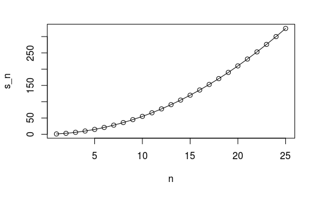

```r
plot(n, s_n)
lines(n, n*(n+1)/2)
```

## 4.5 Vectorization and functionals

```r
x <- 1:10
sqrt(x)
```

```
 [1] 1.000000 1.414214 1.732051 2.000000 2.236068 2.449490 2.645751
 [8] 2.828427 3.000000 3.162278
```

```r
y <- 1:10
x*y
```

```
 [1]   1   4   9  16  25  36  49  64  81 100
```

`Seqeunce`로 지정을 했을 때 각 수를 하나의 element로 보는 것이 아닌 sequence를 scalar로 보기 때문에 sequence의 첫번재 수만 인식하여 `compute_s_n`에 사용한다.

```r
n <- 1:25
compute_s_n(n)
```

```
numerical expression has 25 elements: only the first used
```

```
[1] 1
```

The function `sapply` permits us to perform element-wise operations on any function.

```r
x <- 1:10
sapply(x, sqrt)
```

```
 [1] 1.000000 1.414214 1.732051 2.000000 2.236068 2.449490 2.645751
 [8] 2.828427 3.000000 3.162278
```

결과적으로 `sapply`를 이용하면 지정한 값을 element-wise로 인식한다. 따라서 앞서 사용했던 compute_s_n에 `sapply`를 이용하면 기대하던 값을 얻을 수 있다.

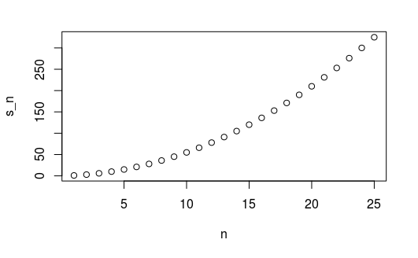

```r
n <- 1:25
s_n <- sapply(n, compute_s_n)
plot(n, s_n)
```

## 4.6 Exercises

1. What will this conditional expression return?

```r
x <- c(1,2,-3,4)

if(all(x>0)){
  print("All Postives")
} else{
  print("Not all positives")
}
```

```
[1] "Not all positives"
```

2. Which of the following expressions is always `FALSE` when at least one entry of a logical vector `x` is TRUE?

```r
x <- c(TRUE, TRUE, FALSE)
all(x)
```

```
[1] FALSE
```

```r
any(x)
```

```
[1] TRUE
```

```r
any(!x)
```

```
[1] TRUE
```

```r
all(!x)
```

```
[1] FALSE
```

A. `all(x)` B. `any(x)` C. `any(!x)` **D. `all(!x)`**

3. The function `nchar` tells you how many characters long a character vector is. Write a line of code that assigns to the object `new_names` the state abbreviation when the state name is longer than 8 characters.

```r
state_8 <- nchar(murders$state) > 8
```

```
Error in nchar(murders$state) : object 'murders' not found
```

4. Create a function `sum_n` that for any given value, say *n*, computes the sum of the integers from 1 to n (inclusive). Use the function to determine the sum of integers from 1 to 5,000.

```
[1] 12502500
```

print(x)

```
[1] 3
```

x의 value는 3인 것을 알 수 있다.

```
[1] 385
```

8. Define an empty numerical vector `s_n` of size 25 using `s_n <- vector("numeric", 25)` and store in the results of S1, S2, … S25 using a for-loop.

s_n

```
 [1]    1    5   14   30   55   91  140  204  285  385  506  650  819
[14] 1015 1240 1496 1785 2109 2470 2870 3311 3795 4324 4900 5525
```

9. Repeat exercise 8, but this time use `sapply`.

s_n

```
 [1]    1    5   14   30   55   91  140  204  285  385  506  650  819
[14] 1015 1240 1496 1785 2109 2470 2870 3311 3795 4324 4900 5525
```

10. Repeat exercise 8, but this time use `map_dbl`

s_n

```
 [1]    1    5   14   30   55   91  140  204  285  385  506  650  819
[14] 1015 1240 1496 1785 2109 2470 2870 3311 3795 4324 4900 5525
```

11. Plot *Sn* versus *n*. Use points defined by n = 1,…,25.

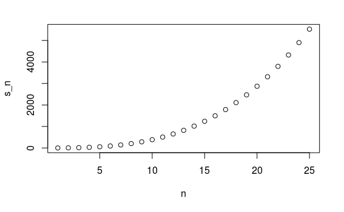

12. Confirm that the formula for this sum is Sn=n(n+1)(2n+1)/6

```r
s_n = s_n
formula = n*(n+1)*(2n+1)/6
```

```
Error: unexpected symbol in "formula = n*(n+1)*(2n"
```

?error 뜨는 이유